# Examen

```r
library(tidyverse)
StackOverflow <- read.csv("survey_results_public.csv")
```

Exploratory Analysis

# 1.- Do you contribute to open source projects?

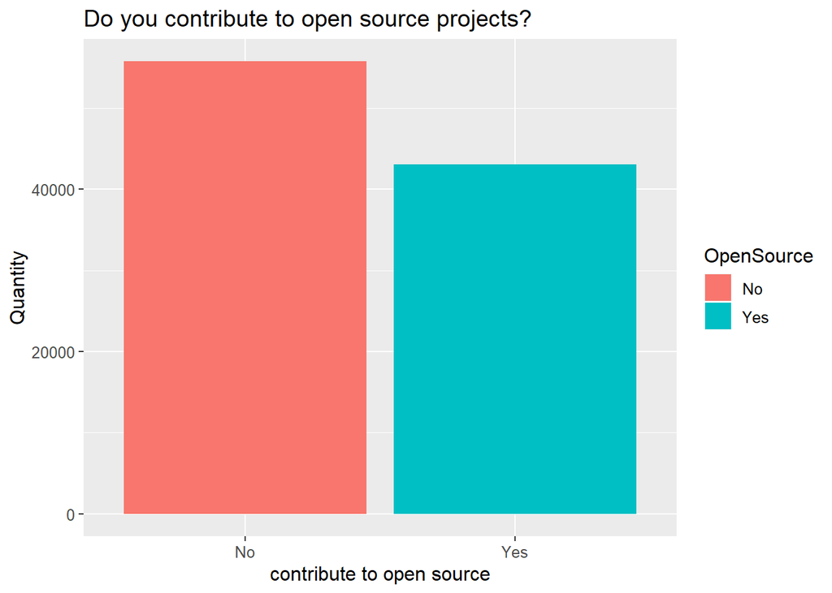

```r
OpenSourceGraf <- ggplot(data = StackOverflow) +
  geom_bar(mapping = aes(x = OpenSource, fill = OpenSource))

Pregunta1 <- OpenSourceGraf + theme (text = element_text(size=12)) +
  ggtitle ("Do you contribute to open source projects?") +
  labs(x = "contribute to open source",y = "Quantity")

Pregunta1
```

The previous graph shows the total number of people who participate and do not participate in Open Source projects.

# 2.- In which country do you currently reside?

```r
Paises <- StackOverflow %>% count(Country) %>%
arrange(desc(n))
```

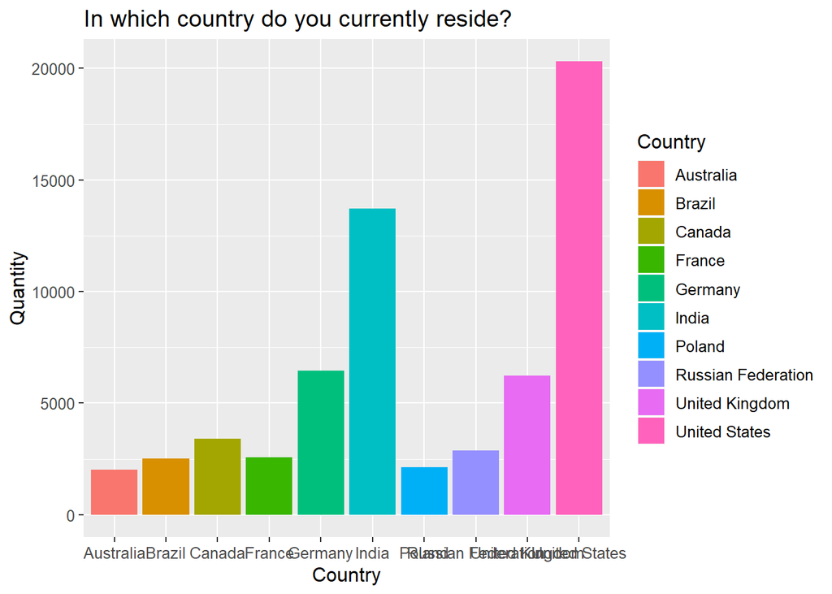

```r
PaisesTop <- head(Paises, 10)

ggplot(PaisesTop, aes(x = Country, y = n, fill = Country)) +
  geom_col() +
  theme (text = element_text(size=12)) +
  ggtitle ("In which country do you currently reside?") +
  labs(x = "Country",y = "Quantity")
```

The graph above shows the number of people in each country, we can see that in the United States is where most of the people who answered the survey.

# 3.- Are you currently enrolled in a formal, degree-granting college or university program?

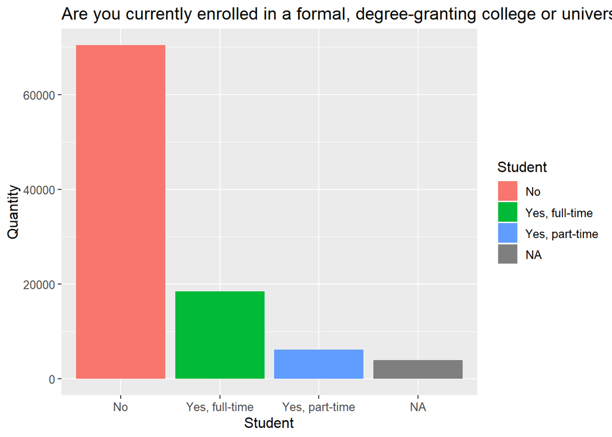

```r
ggplot(data = StackOverflow) +
  geom_bar(mapping = aes(x = Student, fill = Student)) +
  theme (text = element_text(size=12)) +
  ggtitle ("Are you currently enrolled in a formal, degree-granting college or university program?") +
  labs(x = "Student",y = "Quantity")
```

In the previous graph we can see if they are full-time students, part of the time or if they are not studying, where it shows that the majority is no longer a student.

# 4.- Which of the following best describes your current employment status?

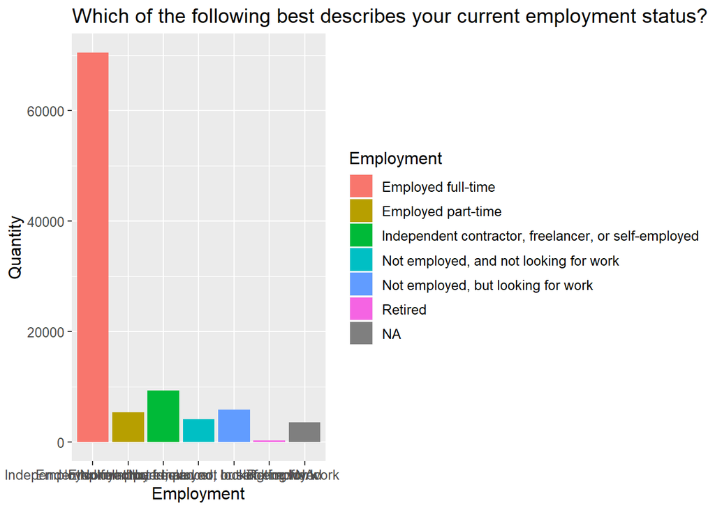

```r
ggplot(data = StackOverflow) +
  geom_bar(mapping = aes(x = Employment, fill = Employment)) +
  theme (text = element_text(size=12)) +
  ggtitle ("Which of the following best describes your current employment status?") +
  labs(x = "Employment",y = "Quantity")
```

The previous graph shows the current employment status of the people surveyed. More than 60,000 people are employed full-time.

# 5.- Which of the following best describes the highest level of formal education that you’ve completed?

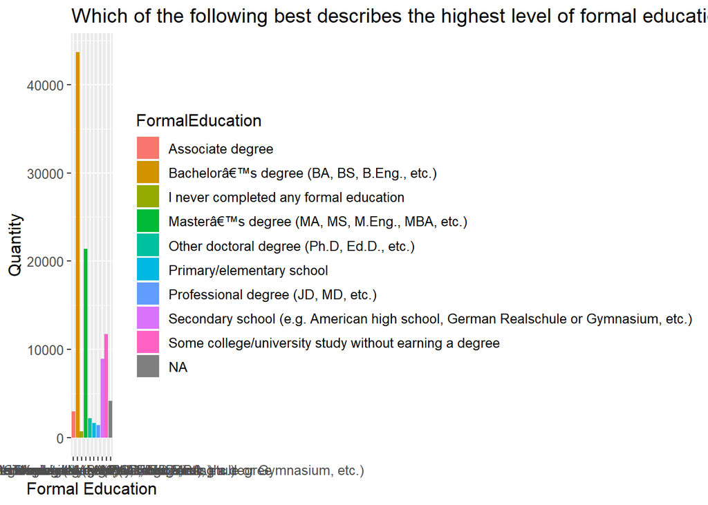

```r
ggplot(data = StackOverflow) +
  geom_bar(mapping = aes(x = FormalEducation, fill = FormalEducation)) +
  theme (text = element_text(size=12)) +
  ggtitle ("Which of the following best describes the highest level of formal education that you’ve completed?") +
  labs(x = "Formal Education",y = "Quantity")
```

This graph shows us to what degree of formal education the people who answered the survey arrived.

```r
SETAP <- read.csv("Software Engineering Team Assessment and Prediction (SETAP) Project - Sheet1.csv")
```

# 1.-How many observations per year?

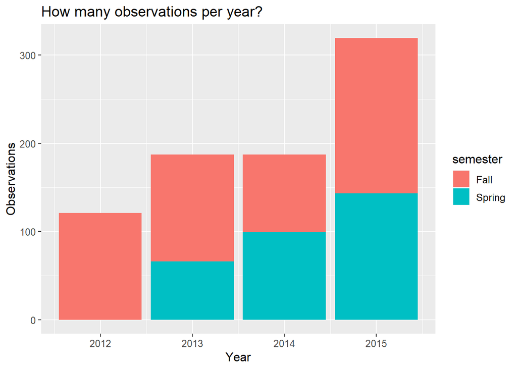

```r
ggplot(data = SETAP) +
  geom_bar(mapping = aes(x = year, fill = semester)) +
  theme (text = element_text(size=12)) +
  ggtitle ("How many observations per year?") +
  labs(x = "Year",y = "Observations")
```

The previous graph shows the total of observations per year divided in each of the semesters.In 2015, there were more observations.

# 2.- In which year and season the collection data process began?

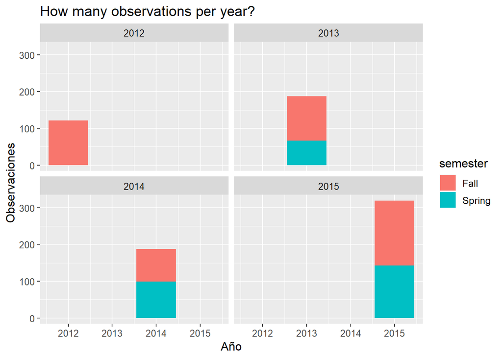

```r
ggplot(data = SETAP) +
  geom_bar(mapping = aes(x = year, fill = semester)) +
  theme (text = element_text(size=12)) +
  ggtitle ("How many observations per year?") +
  labs(x = "Año",y = "Observaciones") +
  facet_wrap( ~ year)
```

This graph shows us in what year and season the data collection process began.This was in the fall of 2012.

# 3.- How many observations the data shows per gender (male vs female) in total. And how many observations per gender (male vs female) is divided by year?

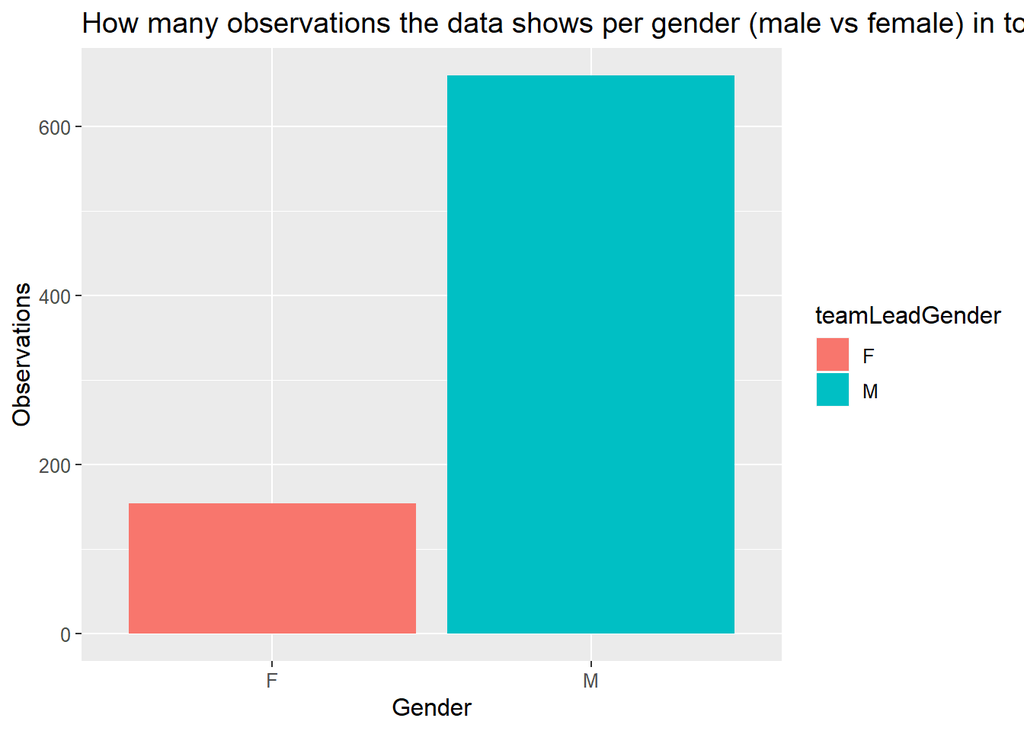

```r
ggplot(data = SETAP) +
  geom_bar(mapping = aes(x = teamLeadGender, fill = teamLeadGender)) +
  theme (text = element_text(size=12)) +
  ggtitle ("How many observations the data shows per gender (male vs female) in total") +
  labs(x = "Gender",y = "Observations")
```

This graph shows us the total of observations for each gender. They were more men than women.

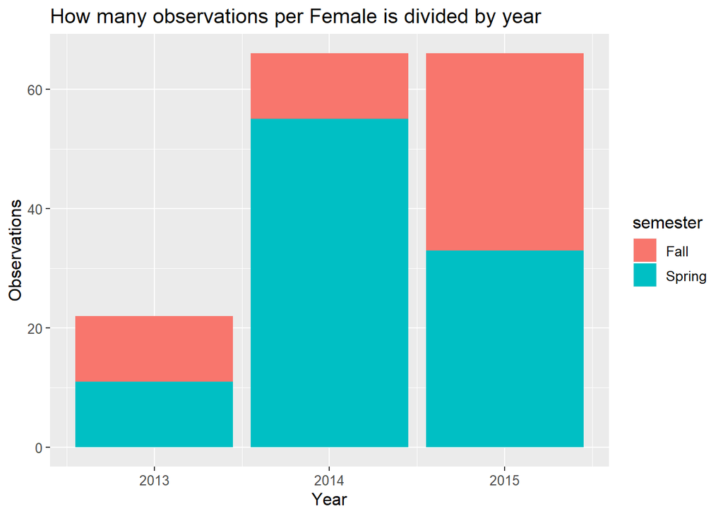

```r
SETAP %>%
  filter(teamLeadGender == "F") %>%
  ggplot(aes(x = year, fill = semester))+
  geom_bar() +
  theme (text = element_text(size=12)) +
  ggtitle ("How many observations per Female is divided by year") +
  labs(x = "Year",y = "Observations")
```

This graph shows the total number of observations for each year and season of the women.

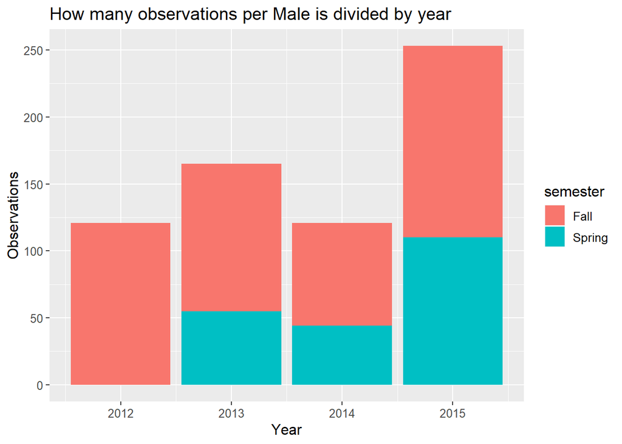

```r
SETAP %>%
  filter(teamLeadGender == "M") %>%
  ggplot(aes(x = year, fill = semester))+
  geom_bar() +
  theme (text = element_text(size=12)) +
  ggtitle ("How many observations per Male is divided by year") +
  labs(x = "Year",y = "Observations")
```

This graph shows the total number of observations for each year and season of the men.